- 이번예제는 우리나라의 인구 소멸 위기 지역에 대해 조사할 예정이다. 인구 소멸 위기 지역을 시각화해서 위기감을 일으키는 것이 목족이다.
- 그러기 위해서는 이전예제에서 했던 서울시 지도가 아니라 대한민국 지도를 활용해 그려야 한다.(대한민국 지도를 그리고 그 위에 인구 소멸 위기 지역에 대해 매핑을 최종목표로 코드를 짜보도록 해본다.)

# 5-1 목표 정확히 하기

### 인구 소멸 위기 지역:

- 이상호 한국고용정보원 연구원의< 한국의 지방소멸에 관한 7가지 분석 >이라는 보고서에서 사용한 방법으로, 인구소멸지역의 정의를 65세 이상 노인 인구와 20~39세 여성 인구를 비교해서 젊은 여성인구가 노인 인구의 절반에 미달할 경우 인구 소멸 위험 지역으로 분류하는 방법을 사용할 예정이다.
- 이 방식에 따라 먼저 각 지역별20~30대 여성 인구수를 파악해야 하며, 또 65세 이상 노인 인구수를 파악해야 한다. 또한 인구 소멸 위기 지역인지 파악해야 한다.
- 그리고 한 단계 더 나아가 한국 자도에 시각화 하기 위해 한국 지도를 그리는 법을 알아야 한다.(Folium을 이용한 방법과 또 다른 방법을 사용)

# 5-2 인구 데이터 확보하고 정리하기

- 국가통계포털 http://kosis.kr/index/index.do 에 접속하여 인구 가구 > 인구총조사 > 인구부문 > 총조사인구(2015년 이후) > 전수부문 > 전수기본표 > 성 연령 및 세대 구성별 인구 - 시군구를 선택하고 다시 각 지역별 항목과 필요한 연령대별 항목을 선택해서 데이터를 받는다.
- 편의를 위해 미리 준비한 데이터를 사용한다(2016년)

```python
# 폰트설정

import pandas as pd
import numpy as np

import platform
import matplotlib.pyplot as plt

%matplotlib inline

path = "c:/Windows/Fonts/malgun.ttf"
from matplotlib import font_manager, rc
if platform.system() == 'Darwin':
    rc('font', family='AppleGothic')
elif platform.system() == 'Windows':
    font_name = font_manager.FontProperties(fname=path).get_name()
    rc('font', family=font_name)
else:
    print('Unknown system... sorry~~~~')

plt.rcParams['axes.unicode_minus'] = False
```

```python
# 데이터 읽어오기, 빈셀에 대해 NaN처리 하지 않고 그 앞 내용으로 채워준다.
# '소계' 라는 항목 삭제

population = pd.read_excel('../data/05. population_raw_data.xlsx', header=1)
population.fillna(method='pad', inplace=True)


population.rename(columns = {'행정구역(동읍면)별(1)':'광역시도',
                             '행정구역(동읍면)별(2)':'시도',
                             '계':'인구수'}, inplace=True)

population = population[(population['시도'] != '소계')]

population.head()
```

|  | 광역시도 | 시도 | 항목 | 인구수 | 20 - 24세 | 25 - 29세 | 30 - 34세 | 35 - 39세 | 65 - 69세 | 70 - 74세 | 75 - 79세 | 80 - 84세 | 85 - 89세 | 90 - 94세 | 95 - 99세 | 100+ |
| --- | --- | --- | --- | --- | --- | --- | --- | --- | --- | --- | --- | --- | --- | --- | --- | --- |
| 6 | 서울특별시 | 종로구 | 총인구수 (명) | 152737.0 | 11379.0 | 11891.0 | 10684 | 10379.0 | 7411.0 | 6636.0 | 5263 | 3104.0 | 1480.0 | 602.0 | 234 | 220.0 |
| 7 | 서울특별시 | 종로구 | 남자인구수 (명) | 75201.0 | 5620.0 | 6181.0 | 5387 | 5034.0 | 3411.0 | 3009.0 | 2311 | 1289.0 | 506.0 | 207.0 | 89 | 73.0 |
| 8 | 서울특별시 | 종로구 | 여자인구수 (명) | 77536.0 | 5759.0 | 5710.0 | 5297 | 5345.0 | 4000.0 | 3627.0 | 2952 | 1815.0 | 974.0 | 395.0 | 145 | 147.0 |
| 9 | 서울특별시 | 중구 | 총인구수 (명) | 125249.0 | 8216.0 | 9529.0 | 10332 | 10107.0 | 6399.0 | 5313.0 | 4127 | 2502.0 | 1260.0 | 469.0 | 158 | 160.0 |
| 10 | 서울특별시 | 중구 | 남자인구수 (명) | 62204.0 | 4142.0 | 4792.0 | 5192 | 5221.0 | 3113.0 | 2405.0 | 1752 | 929.0 | 414.0 | 132.0 | 56 | 51.0 |

```python
# '항목'컬럼을 '구분'컬럼으로 이름을 변경한다.
# '총인구수' 처럼 긴 이름은 간단하게 표현한다.

population.rename(columns = {'항목':'구분'}, inplace=True)

population.loc[population['구분'] == '총인구수 (명)', '구분'] = '합계'
population.loc[population['구분'] == '남자인구수 (명)', '구분'] = '남자'
population.loc[population['구분'] == '여자인구수 (명)', '구분'] = '여자'

population.head()
```

|  | 광역시도 | 시도 | 구분 | 인구수 | 20 - 24세 | 25 - 29세 | 30 - 34세 | 35 - 39세 | 65 - 69세 | 70 - 74세 | 75 - 79세 | 80 - 84세 | 85 - 89세 | 90 - 94세 | 95 - 99세 | 100+ |
| --- | --- | --- | --- | --- | --- | --- | --- | --- | --- | --- | --- | --- | --- | --- | --- | --- |
| 6 | 서울특별시 | 종로구 | 합계 | 152737.0 | 11379.0 | 11891.0 | 10684 | 10379.0 | 7411.0 | 6636.0 | 5263 | 3104.0 | 1480.0 | 602.0 | 234 | 220.0 |
| 7 | 서울특별시 | 종로구 | 남자 | 75201.0 | 5620.0 | 6181.0 | 5387 | 5034.0 | 3411.0 | 3009.0 | 2311 | 1289.0 | 506.0 | 207.0 | 89 | 73.0 |
| 8 | 서울특별시 | 종로구 | 여자 | 77536.0 | 5759.0 | 5710.0 | 5297 | 5345.0 | 4000.0 | 3627.0 | 2952 | 1815.0 | 974.0 | 395.0 | 145 | 147.0 |
| 9 | 서울특별시 | 중구 | 합계 | 125249.0 | 8216.0 | 9529.0 | 10332 | 10107.0 | 6399.0 | 5313.0 | 4127 | 2502.0 | 1260.0 | 469.0 | 158 | 160.0 |
| 10 | 서울특별시 | 중구 | 남자 | 62204.0 | 4142.0 | 4792.0 | 5192 | 5221.0 | 3113.0 | 2405.0 | 1752 | 929.0 | 414.0 | 132.0 | 56 | 51.0 |

# 5-3 인구 소멸 위기 지역 계산하고 데이터 정리하기

```python
# 65세 이상 노인인구와 20~39세 여성 인구를 구한다.

population['20-39세'] = population['20 - 24세'] + population['25 - 29세'] + \
                        population['30 - 34세'] + population['35 - 39세']

population['65세이상'] = population['65 - 69세'] + population['70 - 74세'] + \
                        population['75 - 79세'] + population['80 - 84세'] + \
                        population['85 - 89세'] + population['90 - 94세'] + \
                        population['95 - 99세'] + population['100+']

population.head(10)
```

|  | 광역시도 | 시도 | 구분 | 인구수 | 20 - 24세 | 25 - 29세 | 30 - 34세 | 35 - 39세 | 65 - 69세 | 70 - 74세 | 75 - 79세 | 80 - 84세 | 85 - 89세 | 90 - 94세 | 95 - 99세 | 100+ | 20-39세 | 65세이상 |
| --- | --- | --- | --- | --- | --- | --- | --- | --- | --- | --- | --- | --- | --- | --- | --- | --- | --- | --- |
| 6 | 서울특별시 | 종로구 | 합계 | 152737.0 | 11379.0 | 11891.0 | 10684 | 10379.0 | 7411.0 | 6636.0 | 5263 | 3104.0 | 1480.0 | 602.0 | 234 | 220.0 | 44333.0 | 24950.0 |
| 7 | 서울특별시 | 종로구 | 남자 | 75201.0 | 5620.0 | 6181.0 | 5387 | 5034.0 | 3411.0 | 3009.0 | 2311 | 1289.0 | 506.0 | 207.0 | 89 | 73.0 | 22222.0 | 10895.0 |
| 8 | 서울특별시 | 종로구 | 여자 | 77536.0 | 5759.0 | 5710.0 | 5297 | 5345.0 | 4000.0 | 3627.0 | 2952 | 1815.0 | 974.0 | 395.0 | 145 | 147.0 | 22111.0 | 14055.0 |
| 9 | 서울특별시 | 중구 | 합계 | 125249.0 | 8216.0 | 9529.0 | 10332 | 10107.0 | 6399.0 | 5313.0 | 4127 | 2502.0 | 1260.0 | 469.0 | 158 | 160.0 | 38184.0 | 20388.0 |
| 10 | 서울특별시 | 중구 | 남자 | 62204.0 | 4142.0 | 4792.0 | 5192 | 5221.0 | 3113.0 | 2405.0 | 1752 | 929.0 | 414.0 | 132.0 | 56 | 51.0 | 19347.0 | 8852.0 |
| 11 | 서울특별시 | 중구 | 여자 | 63045.0 | 4074.0 | 4737.0 | 5140 | 4886.0 | 3286.0 | 2908.0 | 2375 | 1573.0 | 846.0 | 337.0 | 102 | 109.0 | 18837.0 | 11536.0 |
| 12 | 서울특별시 | 용산구 | 합계 | 230241.0 | 14317.0 | 16972.0 | 19032 | 19127.0 | 10675.0 | 9093.0 | 7477 | 4553.0 | 2254.0 | 916.0 | 264 | 315.0 | 69448.0 | 35547.0 |
| 13 | 서울특별시 | 용산구 | 남자 | 111601.0 | 6937.0 | 8373.0 | 9455 | 9434.0 | 4834.0 | 3975.0 | 3094 | 1739.0 | 750.0 | 284.0 | 102 | 88.0 | 34199.0 | 14866.0 |
| 14 | 서울특별시 | 용산구 | 여자 | 118640.0 | 7380.0 | 8599.0 | 9577 | 9693.0 | 5841.0 | 5118.0 | 4383 | 2814.0 | 1504.0 | 632.0 | 162 | 227.0 | 35249.0 | 20681.0 |
| 15 | 서울특별시 | 성동구 | 합계 | 299259.0 | 20813.0 | 23383.0 | 25507 | 25979.0 | 12938.0 | 10734.0 | 7989 | 4450.0 | 1944.0 | 678.0 | 209 | 198.0 | 95682.0 | 39140.0 |

```python
pop = pd.pivot_table(population,
                     index = ['광역시도', '시도'],
                     columns = ['구분'],
                     values = ['인구수', '20-39세', '65세이상'])
pop.head()
```

| 광역시도 | 구분 시도 | 20-39세 남자 | 20-39세 여자 | 20-39세 합계 | 65세이상 남자 | 65세이상 여자 | 65세이상 합계 | 인구수 남자 | 인구수 여자 | 인구수 합계 |
| --- | --- | --- | --- | --- | --- | --- | --- | --- | --- | --- |
| 강원도 | 강릉시 | 26286.0 | 23098.0 | 49384.0 | 15767.0 | 21912.0 | 37679.0 | 106231.0 | 107615.0 | 213846.0 |
|  | 고성군 | 4494.0 | 2529.0 | 7023.0 | 2900.0 | 4251.0 | 7151.0 | 15899.0 | 14215.0 | 30114.0 |
|  | 동해시 | 11511.0 | 9753.0 | 21264.0 | 6392.0 | 8732.0 | 15124.0 | 47166.0 | 46131.0 | 93297.0 |
|  | 삼척시 | 8708.0 | 7115.0 | 15823.0 | 5892.0 | 8718.0 | 14610.0 | 35253.0 | 34346.0 | 69599.0 |
|  | 속초시 | 9956.0 | 8752.0 | 18708.0 | 5139.0 | 7613.0 | 12752.0 | 40288.0 | 41505.0 | 81793.0 |

- pivot_table을 이용하여 광역시도, 시도를 index로 두고, 구분으로 세로를 첫 번째 컬럼을 잡고, value에 인구수, 20~39세, 65세이상으로 정리해 둔다.

```python
pop['소멸비율'] = pop['20-39세','여자'] / (pop['65세이상','합계'] / 2)
pop.head()
```

| 광역시도 | 구분 시도 | 20-39세 남자 | 20-39세 여자 | 20-39세 합계 | 65세이상 남자 | 65세이상 여자 | 65세이상 합계 | 인구수 남자 | 인구수 여자 | 인구수 합계 | 소멸비율 |
| --- | --- | --- | --- | --- | --- | --- | --- | --- | --- | --- | --- |
| 강원도 | 강릉시 | 26286.0 | 23098.0 | 49384.0 | 15767.0 | 21912.0 | 37679.0 | 106231.0 | 107615.0 | 213846.0 | 1.226041 |
|  | 고성군 | 4494.0 | 2529.0 | 7023.0 | 2900.0 | 4251.0 | 7151.0 | 15899.0 | 14215.0 | 30114.0 | 0.707314 |
|  | 동해시 | 11511.0 | 9753.0 | 21264.0 | 6392.0 | 8732.0 | 15124.0 | 47166.0 | 46131.0 | 93297.0 | 1.289738 |
|  | 삼척시 | 8708.0 | 7115.0 | 15823.0 | 5892.0 | 8718.0 | 14610.0 | 35253.0 | 34346.0 | 69599.0 | 0.973990 |
|  | 속초시 | 9956.0 | 8752.0 | 18708.0 | 5139.0 | 7613.0 | 12752.0 | 40288.0 | 41505.0 | 81793.0 | 1.372647 |

```python
pop['소멸위기지역'] = pop['소멸비율'] < 1.0
pop.head()
```

| 광역시도 | 구분 시도 | 20-39세 남자 | 20-39세 여자 | 20-39세 합계 | 65세이상 남자 | 65세이상 여자 | 65세이상 합계 | 인구수 남자 | 인구수 여자 | 인구수 합계 | 소멸비율 | 소멸위기지역 |
| --- | --- | --- | --- | --- | --- | --- | --- | --- | --- | --- | --- | --- |
| 강원도 | 강릉시 | 26286.0 | 23098.0 | 49384.0 | 15767.0 | 21912.0 | 37679.0 | 106231.0 | 107615.0 | 213846.0 | 1.226041 | False |
|  | 고성군 | 4494.0 | 2529.0 | 7023.0 | 2900.0 | 4251.0 | 7151.0 | 15899.0 | 14215.0 | 30114.0 | 0.707314 | True |
|  | 동해시 | 11511.0 | 9753.0 | 21264.0 | 6392.0 | 8732.0 | 15124.0 | 47166.0 | 46131.0 | 93297.0 | 1.289738 | False |
|  | 삼척시 | 8708.0 | 7115.0 | 15823.0 | 5892.0 | 8718.0 | 14610.0 | 35253.0 | 34346.0 | 69599.0 | 0.973990 | True |
|  | 속초시 | 9956.0 | 8752.0 | 18708.0 | 5139.0 | 7613.0 | 12752.0 | 40288.0 | 41505.0 | 81793.0 | 1.372647 | False |

- 소멸비율이라는 컬럼에 인구소멸위기지역을 계산하기 위한 식을 적용한다.
- 이 비율이 1보다 작으면 인구소멸위기지역으로 볼 수 있다.
- 인구 소멸비율: 20-30대 여자 / (65세 이상/2)
- 소멸위기지역: 소멸비율 < 1.0
- 소멸위기지역인지를 boolean으로 지정해 둔다

```python
pop[pop['소멸위기지역']==True].index.get_level_values(1)
```

```
Index(['고성군', '삼척시', '양양군', '영월군', '정선군', '평창군', '홍천군', '횡성군', '가평군', '양평군',
       '연천군', '거창군', '고성군', '남해군', '밀양시', '산청군', '의령군', '창녕군', '하동군', '함안군',
       '함양군', '합천군', '고령군', '군위군', '문경시', '봉화군', '상주시', '성주군', '영덕군', '영양군',
       '영주시', '영천시', '예천군', '울릉군', '울진군', '의성군', '청도군', '청송군', '동구', '영도구',
       '강화군', '옹진군', '강진군', '고흥군', '곡성군', '구례군', '담양군', '보성군', '신안군', '영광군',
       '영암군', '완도군', '장성군', '장흥군', '진도군', '함평군', '해남군', '화순군', '고창군', '김제시',
       '남원시', '무주군', '부안군', '순창군', '임실군', '장수군', '정읍시', '진안군', '공주시', '금산군',
       '논산시', '보령시', '부여군', '서천군', '예산군', '청양군', '태안군', '홍성군', '괴산군', '단양군',
       '보은군', '영동군', '옥천군'],
      dtype='object', name='시도')
```

- multiple columns에서 값 뽑기: df.index.get_level_values(1)을 이용하여, 소멸위기지역인 곳을 확인 할 수 있다.

```python
# pivot_table에 의해 다단으로 구성된 index를 다시 초기화한다.

pop.reset_index(inplace=True)
pop.head()
```

| 구분 | 광역시도 | 시도 | 20-39세 남자 | 20-39세 여자 | 20-39세 합계 | 65세이상 남자 | 65세이상 여자 | 65세이상 합계 | 인구수 남자 | 인구수 여자 | 인구수 합계 | 소멸비율 | 소멸위기지역 |
| --- | --- | --- | --- | --- | --- | --- | --- | --- | --- | --- | --- | --- | --- |
| 0 | 강원도 | 강릉시 | 26286.0 | 23098.0 | 49384.0 | 15767.0 | 21912.0 | 37679.0 | 106231.0 | 107615.0 | 213846.0 | 1.226041 | False |
| 1 | 강원도 | 고성군 | 4494.0 | 2529.0 | 7023.0 | 2900.0 | 4251.0 | 7151.0 | 15899.0 | 14215.0 | 30114.0 | 0.707314 | True |
| 2 | 강원도 | 동해시 | 11511.0 | 9753.0 | 21264.0 | 6392.0 | 8732.0 | 15124.0 | 47166.0 | 46131.0 | 93297.0 | 1.289738 | False |
| 3 | 강원도 | 삼척시 | 8708.0 | 7115.0 | 15823.0 | 5892.0 | 8718.0 | 14610.0 | 35253.0 | 34346.0 | 69599.0 | 0.973990 | True |
| 4 | 강원도 | 속초시 | 9956.0 | 8752.0 | 18708.0 | 5139.0 | 7613.0 | 12752.0 | 40288.0 | 41505.0 | 81793.0 | 1.372647 | False |

- pivot_table로 잘 정리가 된 상태에서 .reset_index로 pivot_table의 result 속성을 다시 설정한다.

```python
tmp_coloumns = [pop.columns.get_level_values(0)[n] + \
                pop.columns.get_level_values(1)[n]
                for n in range(0,len(pop.columns.get_level_values(0)))]

pop.columns = tmp_coloumns

pop.head()
```

|  | 광역시도 | 시도 | 20-39세남자 | 20-39세여자 | 20-39세합계 | 65세이상남자 | 65세이상여자 | 65세이상합계 | 인구수남자 | 인구수여자 | 인구수합계 | 소멸비율 | 소멸위기지역 |
| --- | --- | --- | --- | --- | --- | --- | --- | --- | --- | --- | --- | --- | --- |
| 0 | 강원도 | 강릉시 | 26286.0 | 23098.0 | 49384.0 | 15767.0 | 21912.0 | 37679.0 | 106231.0 | 107615.0 | 213846.0 | 1.226041 | False |
| 1 | 강원도 | 고성군 | 4494.0 | 2529.0 | 7023.0 | 2900.0 | 4251.0 | 7151.0 | 15899.0 | 14215.0 | 30114.0 | 0.707314 | True |
| 2 | 강원도 | 동해시 | 11511.0 | 9753.0 | 21264.0 | 6392.0 | 8732.0 | 15124.0 | 47166.0 | 46131.0 | 93297.0 | 1.289738 | False |
| 3 | 강원도 | 삼척시 | 8708.0 | 7115.0 | 15823.0 | 5892.0 | 8718.0 | 14610.0 | 35253.0 | 34346.0 | 69599.0 | 0.973990 | True |
| 4 | 강원도 | 속초시 | 9956.0 | 8752.0 | 18708.0 | 5139.0 | 7613.0 | 12752.0 | 40288.0 | 41505.0 | 81793.0 | 1.372647 | False |

- 이중 column을 해제하기 위해 두 컬럼 제목을 합쳐 다시 지정한다.

```python
pop.info()
```

```
<class 'pandas.core.frame.DataFrame'>
RangeIndex: 264 entries, 0 to 263
Data columns (total 13 columns):
광역시도        264 non-null object
시도          264 non-null object
20-39세남자    264 non-null float64
20-39세여자    264 non-null float64
20-39세합계    264 non-null float64
65세이상남자     264 non-null float64
65세이상여자     264 non-null float64
65세이상합계     264 non-null float64
인구수남자       264 non-null float64
인구수여자       264 non-null float64
인구수합계       264 non-null float64
소멸비율        264 non-null float64
소멸위기지역      264 non-null bool
dtypes: bool(1), float64(10), object(2)
memory usage: 25.1+ KB
```

- 세로축에 지역, 기로축에 연령대별 혹은 성별 인구수가 정리되었다.
- 총 264개 항목에 인구수는 숫자형으로 잡혔고, 소멸위기지역은 bool형으로 잡혀있다.

# 5-5 지도 시각화를 위해 지역별 고유 ID 만들기

```python
# 고유 ID가 필요
pop['시도'].unique()
```

```
array(['강릉시', '고성군', '동해시', '삼척시', '속초시', '양구군', '양양군', '영월군', '원주시',
       '인제군', '정선군', '철원군', '춘천시', '태백시', '평창군', '홍천군', '화천군', '횡성군',
       '가평군', '고양시', '과천시', '광명시', '광주시', '구리시', '군포시', '권선구', '기흥구',
       '김포시', '남양주시', '단원구', '덕양구', '동두천시', '동안구', '만안구', '부천시', '분당구',
       '상록구', '성남시', '소사구', '수원시', '수정구', '수지구', '시흥시', '안산시', '안성시',
       '안양시', '양주시', '양평군', '여주시', '연천군', '영통구', '오산시', '오정구', '용인시',
       '원미구', '의왕시', '의정부시', '이천시', '일산동구', '일산서구', '장안구', '중원구', '처인구',
       '파주시', '팔달구', '평택시', '포천시', '하남시', '화성시', '거제시', '거창군', '김해시',
       '남해군', '마산합포구', '마산회원구', '밀양시', '사천시', '산청군', '성산구', '양산시', '의령군',
       '의창구', '진주시', '진해구', '창녕군', '창원시', '통영시', '하동군', '함안군', '함양군',
       '합천군', '경산시', '경주시', '고령군', '구미시', '군위군', '김천시', '남구', '문경시',
       '봉화군', '북구', '상주시', '성주군', '안동시', '영덕군', '영양군', '영주시', '영천시',
       '예천군', '울릉군', '울진군', '의성군', '청도군', '청송군', '칠곡군', '포항시', '광산구',
       '동구', '서구', '달서구', '달성군', '수성구', '중구', '대덕구', '유성구', '강서구', '금정구',
       '기장군', '동래구', '부산진구', '사상구', '사하구', '수영구', '연제구', '영도구', '해운대구',
       '강남구', '강동구', '강북구', '관악구', '광진구', '구로구', '금천구', '노원구', '도봉구',
       '동대문구', '동작구', '마포구', '서대문구', '서초구', '성동구', '성북구', '송파구', '양천구',
       '영등포구', '용산구', '은평구', '종로구', '중랑구', '세종특별자치시', '울주군', '강화군', '계양구',
       '남동구', '부평구', '연수구', '옹진군', '강진군', '고흥군', '곡성군', '광양시', '구례군',
       '나주시', '담양군', '목포시', '무안군', '보성군', '순천시', '신안군', '여수시', '영광군',
       '영암군', '완도군', '장성군', '장흥군', '진도군', '함평군', '해남군', '화순군', '고창군',
       '군산시', '김제시', '남원시', '덕진구', '무주군', '부안군', '순창군', '완산구', '완주군',
       '익산시', '임실군', '장수군', '전주시', '정읍시', '진안군', '서귀포시', '제주시', '계룡시',
       '공주시', '금산군', '논산시', '당진시', '동남구', '보령시', '부여군', '서북구', '서산시',
       '서천군', '아산시', '예산군', '천안시', '청양군', '태안군', '홍성군', '괴산군', '단양군',
       '보은군', '상당구', '서원구', '영동군', '옥천군', '음성군', '제천시', '증평군', '진천군',
       '청원구', '청주시', '충주시', '흥덕구'], dtype=object)
```

- 인천, 부산 등 광역시의 구(자치구)도 있지만, 안양시나 수원시에 있는 구(행정구)도 있다.
- 고유 아이디를 '광역시도'의 값과 '시도'의 값을 합쳐서 보도록 한다.

```python
si_name = [None] * len(pop)

tmp_gu_dict = {'수원':['장안구', '권선구', '팔달구', '영통구'],
                       '성남':['수정구', '중원구', '분당구'],
                       '안양':['만안구', '동안구'],
                       '안산':['상록구', '단원구'],
                       '고양':['덕양구', '일산동구', '일산서구'],
                       '용인':['처인구', '기흥구', '수지구'],
                       '청주':['상당구', '서원구', '흥덕구', '청원구'],
                       '천안':['동남구', '서북구'],
                       '전주':['완산구', '덕진구'],
                       '포항':['남구', '북구'],
                       '창원':['의창구', '성산구', '진해구', '마산합포구', '마산회원구'],
                       '부천':['오정구', '원미구', '소사구']}
```

- 시와 구로 나누어 dictionary에 저장한다,
- 광역시가 아니면서 구를 가지고 있는 시와 행정구를 dict에 저장한다.

```python
for n in pop.index:
    # [-3:] 끝 3글자
    if pop['광역시도'][n][-3:] not in ['광역시', '특별시', '자치시']:
        # [:-1] 끝 1글자 빼고 나머지
        if pop['시도'][n][:-1]=='고성' and pop['광역시도'][n]=='강원도':
            si_name[n] = '고성(강원)'
        elif pop['시도'][n][:-1]=='고성' and pop['광역시도'][n]=='경상남도':
            si_name[n] = '고성(경남)'
        else:
             si_name[n] = pop['시도'][n][:-1]

        for keys, values in tmp_gu_dict.items():
            if pop['시도'][n] in values:
                if len(pop['시도'][n])==2:
                    si_name[n] = keys + ' ' + pop['시도'][n]
                elif pop['시도'][n] in ['마산합포구','마산회원구']:
                    si_name[n] = keys + ' ' + pop['시도'][n][2:-1]
                else:
                    si_name[n] = keys + ' ' + pop['시도'][n][:-1]

    elif pop['광역시도'][n] == '세종특별자치시':
        si_name[n] = '세종'

    else:
        if len(pop['시도'][n])==2:
            si_name[n] = pop['광역시도'][n][:2] + ' ' + pop['시도'][n]
        else:
            # '시도'가 3글자 이상이면 보통 뒤에 구, 군, 시 등이 붙으므로 2글자로 맞춰줌
            si_name[n] = pop['광역시도'][n][:2] + ' ' + pop['시도'][n][:-1]

si_name[:20]
```

```
['강릉',
 '고성(강원)',
 '동해',
 '삼척',
 '속초',
 '양구',
 '양양',
 '영월',
 '원주',
 '인제',
 '정선',
 '철원',
 '춘천',
 '태백',
 '평창',
 '홍천',
 '화천',
 '횡성',
 '가평',
 '고양']
```

- 지도 시각화에 사용하기 위해 위 과정에서 만들어진 행정구역의 고유한 이름을 ID로 지정한다
- '광역시', '특별시', '자치시'로 끝나지 않으면 일반 시 혹은 군으로 본다.
- '세종특별자치시'는 그냥 '세종'으로 처리하고, 나머지는 광역시도 앞 에서 두 글자(서울특별시)와 시도에서 두 글자인 경우 모두, 아니면 앞 두 글자만 선택하면서 고유 ID를 만들어 준다.

```python
# 결과를 pop에 포함시킨다.

pop['ID'] = si_name
pop.head(3)
```

|  | 광역시도 | 시도 | 20-39세남자 | 20-39세여자 | 20-39세합계 | 65세이상남자 | 65세이상여자 | 65세이상합계 | 인구수남자 | 인구수여자 | 인구수합계 | 소멸비율 | 소멸위기지역 | ID |
| --- | --- | --- | --- | --- | --- | --- | --- | --- | --- | --- | --- | --- | --- | --- |
| 0 | 강원도 | 강릉시 | 26286.0 | 23098.0 | 49384.0 | 15767.0 | 21912.0 | 37679.0 | 106231.0 | 107615.0 | 213846.0 | 1.226041 | False | 강릉 |
| 1 | 강원도 | 고성군 | 4494.0 | 2529.0 | 7023.0 | 2900.0 | 4251.0 | 7151.0 | 15899.0 | 14215.0 | 30114.0 | 0.707314 | True | 고성(강원) |
| 2 | 강원도 | 동해시 | 11511.0 | 9753.0 | 21264.0 | 6392.0 | 8732.0 | 15124.0 | 47166.0 | 46131.0 | 93297.0 | 1.289738 | False | 동해 |

```python
# 큰 의미가 없는 몇몇 컬럼은 제거해준다.

del pop['20-39세남자']
del pop['65세이상남자']
del pop['65세이상여자']

pop.head(3)
```

|  | 광역시도 | 시도 | 20-39세여자 | 20-39세합계 | 65세이상합계 | 인구수남자 | 인구수여자 | 인구수합계 | 소멸비율 | 소멸위기지역 | ID |
| --- | --- | --- | --- | --- | --- | --- | --- | --- | --- | --- | --- |
| 0 | 강원도 | 강릉시 | 23098.0 | 49384.0 | 37679.0 | 106231.0 | 107615.0 | 213846.0 | 1.226041 | False | 강릉 |
| 1 | 강원도 | 고성군 | 2529.0 | 7023.0 | 7151.0 | 15899.0 | 14215.0 | 30114.0 | 0.707314 | True | 고성(강원) |
| 2 | 강원도 | 동해시 | 9753.0 | 21264.0 | 15124.0 | 47166.0 | 46131.0 | 93297.0 | 1.289738 | False | 동해 |

# 5-6. Cartogram으로 우리나라 지도 만들기

```python
# ID로 나눈 참고 데이터를 불러온다
draw_korea_raw = pd.read_excel('../data/05. draw_korea_raw.xlsx',
                               encoding="EUC-KR")
draw_korea_raw.head()
```

|  | 0 | 1 | 2 | 3 | 4 | 5 | 6 | 7 | 8 | 9 | 10 | 11 | 12 | 13 |
| --- | --- | --- | --- | --- | --- | --- | --- | --- | --- | --- | --- | --- | --- | --- |
| 0 | NaN | NaN | NaN | NaN | NaN | NaN | NaN | 철원 | 화천 | 양구 | 고성(강원) | NaN | NaN | NaN |
| 1 | NaN | NaN | NaN | 양주 | 동두천 | 연천 | 포천 | 의정부 | 인제 | 춘천 | 속초 | NaN | NaN | NaN |
| 2 | NaN | NaN | NaN | 고양 덕양 | 고양 일산동 | 서울 도봉 | 서울 노원 | 남양주 | 홍천 | 횡성 | 양양 | NaN | NaN | NaN |
| 3 | NaN | NaN | 파주 | 고양 일산서 | 김포 | 서울 강북 | 서울 성북 | 가평 | 구리 | 하남 | 정선 | 강릉 | NaN | NaN |
| 4 | NaN | NaN | 부천 소사 | 안양 만안 | 광명 | 서울 서대문 | 서울 종로 | 서울 동대문 | 서울 중랑 | 양평 | 태백 | 동해 | NaN | NaN |

- 각 지역별 위치 x,y 좌표가 필요하기 때문에 밑의 코드를 사용해준다.
- 각 행정 구역의 화면상 좌표를 얻기 위해 pivot_table의 반대 개념으로 .stack() 명령을 사용해 인덱스를 재설정(reset_index)해준다.

```python
draw_korea_raw_stacked = pd.DataFrame(draw_korea_raw.stack())
draw_korea_raw_stacked.reset_index(inplace=True)
draw_korea_raw_stacked.rename(columns={'level_0':'y', 'level_1':'x', 0:'ID'},
                              inplace=True)

draw_korea_raw_stacked.head()
```

|  | y | x | ID |
| --- | --- | --- | --- |
| 0 | 0 | 7 | 철원 |
| 1 | 0 | 8 | 화천 |
| 2 | 0 | 9 | 양구 |
| 3 | 0 | 10 | 고성(강원) |
| 4 | 1 | 3 | 양주 |

```python
draw_korea = draw_korea_raw_stacked
```

- 변수 이름을 다시 설정해 준다.

```python
BORDER_LINES = [
    [(5, 1), (5,2), (7,2), (7,3), (11,3), (11,0)], # 인천
    [(5,4), (5,5), (2,5), (2,7), (4,7), (4,9), (7,9),
     (7,7), (9,7), (9,5), (10,5), (10,4), (5,4)], # 서울
    [(1,7), (1,8), (3,8), (3,10), (10,10), (10,7),
     (12,7), (12,6), (11,6), (11,5), (12, 5), (12,4),
     (11,4), (11,3)], # 경기도
    [(8,10), (8,11), (6,11), (6,12)], # 강원도
    [(12,5), (13,5), (13,4), (14,4), (14,5), (15,5),
     (15,4), (16,4), (16,2)], # 충청북도
    [(16,4), (17,4), (17,5), (16,5), (16,6), (19,6),
     (19,5), (20,5), (20,4), (21,4), (21,3), (19,3), (19,1)], # 전라북도
    [(13,5), (13,6), (16,6)], # 대전시
    [(13,5), (14,5)], #세종시
    [(21,2), (21,3), (22,3), (22,4), (24,4), (24,2), (21,2)], #광주
    [(20,5), (21,5), (21,6), (23,6)], #전라남도
    [(10,8), (12,8), (12,9), (14,9), (14,8), (16,8), (16,6)], #충청북도
    [(14,9), (14,11), (14,12), (13,12), (13,13)], #경상북도
    [(15,8), (17,8), (17,10), (16,10), (16,11), (14,11)], #대구
    [(17,9), (18,9), (18,8), (19,8), (19,9), (20,9), (20,10), (21,10)], #부산
    [(16,11), (16,13)], #울산
#     [(9,14), (9,15)],
    [(27,5), (27,6), (25,6)],
]
```

- ID 컬럼에서 지도에 표기할때 시 이름 구 이름으로 줄을 나누기 위해 분리해준다.

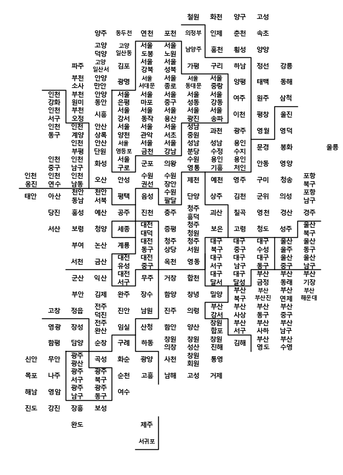

```python
plt.figure(figsize=(8, 11))

# 지역 이름 표시
for idx, row in draw_korea.iterrows():

    # 광역시는 구 이름이 겹치는 경우가 많아서 시단위 이름도 같이 표시한다.
    # (중구, 서구)
    if len(row['ID'].split())==2:
        dispname = '{}\n{}'.format(row['ID'].split()[0], row['ID'].split()[1])
    elif row['ID'][:2]=='고성':
        dispname = '고성'
    else:
        dispname = row['ID']

    # 서대문구, 서귀포시 같이 이름이 3자 이상인 경우에 작은 글자로 표시한다.
    if len(dispname.splitlines()[-1]) >= 3:
        fontsize, linespacing = 9.5, 1.5
    else:
        fontsize, linespacing = 11, 1.2

    plt.annotate(dispname, (row['x']+0.5, row['y']+0.5), weight='bold',
                 fontsize=fontsize, ha='center', va='center',
                 linespacing=linespacing)

# 시도 경계 그린다.
for path in BORDER_LINES:
    ys, xs = zip(*path)
    plt.plot(xs, ys, c='black', lw=1.5)

plt.gca().invert_yaxis()
# invert_yaxis()는 y축이 엑셀에서 0번이 시작하는 것과 matplotlib가 0이라고
# 인식하는 좌표가 반대이기 때문에 사용했다.
#plt.gca().set_aspect(1)

plt.axis('off')

plt.tight_layout()
plt.show()
```

- 광역시도를 구문하는 경계선을 직접 입력한다.
- 인구에 대한 분석 결과인 pop과 지도를 그리기 위한 draw_korea의 데이터를 합칠 때 사용할 key인 ID 컬럼의 내용이 문제가 없는지 확인해본다.

```python
set(draw_korea['ID'].unique()) - set(pop['ID'].unique())
```

```
set()
```

```python
set(pop['ID'].unique()) - set(draw_korea['ID'].unique())
```

```
{'고양', '부천', '성남', '수원', '안산', '안양', '용인', '전주', '창원', '천안', '청주', '포항'}
```

- 위 결과에 따르면, pop에 행정구를 가진 시들의 데이터가 더 있다는 것을 알 수 있다.
- 어차피 지도에서는 표시되지 못하니 삭제한다.

```python
# pop['ID']에서 우리가 만든 draw_korea['ID']에 없는 애들은 빼준다.
tmp_list = list(set(pop['ID'].unique()) - set(draw_korea['ID'].unique()))

for tmp in tmp_list:
    pop = pop.drop(pop[pop['ID']==tmp].index)

print(set(pop['ID'].unique()) - set(draw_korea['ID'].unique()))
```

```
set()
```

```python
pop.head()
```

|  | 광역시도 | 시도 | 20-39세여자 | 20-39세합계 | 65세이상합계 | 인구수남자 | 인구수여자 | 인구수합계 | 소멸비율 | 소멸위기지역 | ID |
| --- | --- | --- | --- | --- | --- | --- | --- | --- | --- | --- | --- |
| 0 | 강원도 | 강릉시 | 23098.0 | 49384.0 | 37679.0 | 106231.0 | 107615.0 | 213846.0 | 1.226041 | False | 강릉 |
| 1 | 강원도 | 고성군 | 2529.0 | 7023.0 | 7151.0 | 15899.0 | 14215.0 | 30114.0 | 0.707314 | True | 고성(강원) |
| 2 | 강원도 | 동해시 | 9753.0 | 21264.0 | 15124.0 | 47166.0 | 46131.0 | 93297.0 | 1.289738 | False | 동해 |
| 3 | 강원도 | 삼척시 | 7115.0 | 15823.0 | 14610.0 | 35253.0 | 34346.0 | 69599.0 | 0.973990 | True | 삼척 |
| 4 | 강원도 | 속초시 | 8752.0 | 18708.0 | 12752.0 | 40288.0 | 41505.0 | 81793.0 | 1.372647 | False | 속초 |

- 이제 pop과 draw_korea의 ID 컬럼이 일치했다고 보고, ID를 key로 merge를 시키도록 한다.

```python
pop = pd.merge(pop, draw_korea, how='left', on=['ID'])

pop.head()
```

|  | 광역시도 | 시도 | 20-39세여자 | 20-39세합계 | 65세이상합계 | 인구수남자 | 인구수여자 | 인구수합계 | 소멸비율 | 소멸위기지역 | ID | y | x |
| --- | --- | --- | --- | --- | --- | --- | --- | --- | --- | --- | --- | --- | --- |
| 0 | 강원도 | 강릉시 | 23098.0 | 49384.0 | 37679.0 | 106231.0 | 107615.0 | 213846.0 | 1.226041 | False | 강릉 | 3 | 11 |
| 1 | 강원도 | 고성군 | 2529.0 | 7023.0 | 7151.0 | 15899.0 | 14215.0 | 30114.0 | 0.707314 | True | 고성(강원) | 0 | 10 |
| 2 | 강원도 | 동해시 | 9753.0 | 21264.0 | 15124.0 | 47166.0 | 46131.0 | 93297.0 | 1.289738 | False | 동해 | 4 | 11 |
| 3 | 강원도 | 삼척시 | 7115.0 | 15823.0 | 14610.0 | 35253.0 | 34346.0 | 69599.0 | 0.973990 | True | 삼척 | 5 | 11 |
| 4 | 강원도 | 속초시 | 8752.0 | 18708.0 | 12752.0 | 40288.0 | 41505.0 | 81793.0 | 1.372647 | False | 속초 | 1 | 10 |

- 이제 위 pop 데이터에서 지도에 표현하고자 하는 데이터가 인구수합계라면 이 값들이 아까 만든 각 해당 행정구역에 위치하면 된다.

### 이제, 정보를 데이터에 그려준다.

```python
mapdata = pop.pivot_table(index='y', columns='x', values='인구수합계')
masked_mapdata = np.ma.masked_where(np.isnan(mapdata), mapdata)
```

```python
mapdata
```

| x y | 0 | 1 | 2 | 3 | 4 | 5 | 6 | 7 | 8 | 9 | 10 | 11 | 12 | 13 |
| --- | --- | --- | --- | --- | --- | --- | --- | --- | --- | --- | --- | --- | --- | --- |
| 0 | NaN | NaN | NaN | NaN | NaN | NaN | NaN | 48013.0 | 26264.0 | 24010.0 | 30114.0 | NaN | NaN | NaN |
| 1 | NaN | NaN | NaN | 205513.0 | 98277.0 | 45907.0 | 154763.0 | 438457.0 | 32720.0 | 280707.0 | 81793.0 | NaN | NaN | NaN |
| 2 | NaN | NaN | NaN | 446233.0 | 292612.0 | 348220.0 | 567581.0 | 662154.0 | 70076.0 | 45991.0 | 27218.0 | NaN | NaN | NaN |
| 3 | NaN | NaN | 430781.000000 | 300839.0 | 363443.0 | 327195.0 | 450355.0 | 62448.0 | 193763.0 | 211101.0 | 38718.0 | 213846.0 | NaN | NaN |
| 4 | NaN | NaN | 283793.333333 | 252353.0 | 339484.0 | 314194.0 | 152737.0 | 355069.0 | 411005.0 | 111367.0 | 47070.0 | 93297.0 | NaN | NaN |
| 5 | NaN | 68010.0 | 283793.333333 | 345061.0 | 491476.0 | 379892.0 | 125249.0 | 299259.0 | 444168.0 | 111563.0 | 337979.0 | 69599.0 | NaN | NaN |
| 6 | NaN | 510733.0 | 283793.333333 | 402888.0 | 595485.0 | 400997.0 | 230241.0 | 357215.0 | 657831.0 | 210359.0 | 43318.0 | 51738.0 | NaN | NaN |
| 7 | NaN | 71014.0 | 330284.000000 | 375857.0 | 477739.0 | 506851.0 | 447192.0 | 237909.0 | 63778.0 | 327723.0 | 40073.0 | 39052.0 | NaN | NaN |
| 8 | NaN | NaN | 549716.000000 | 314002.0 | 370613.0 | 235386.0 | 567115.0 | 503830.0 | 232841.0 | 347833.0 | 74702.0 | 33539.0 | NaN | 10001.0 |
| 9 | NaN | 115249.0 | 417103.000000 | 640890.0 | 417551.0 | 284890.0 | 156763.0 | 340654.0 | 417163.0 | 226130.0 | 168798.0 | 17713.0 | NaN | NaN |
| 10 | 21351.0 | 328627.0 | 530982.000000 | 208656.0 | 182896.0 | 358393.0 | 296479.0 | 136517.0 | 46166.0 | 109247.0 | 419891.0 | 26301.0 | 272027.0 | NaN |
| 11 | 63900.0 | 302929.0 | 258919.000000 | 359036.0 | 470832.0 | 97787.0 | 198515.0 | 30503.0 | 101799.0 | 142256.0 | 24171.0 | 54014.0 | 244748.0 | NaN |
| 12 | NaN | 166630.0 | 99971.000000 | 81339.0 | 109931.0 | 69950.0 | 208350.0 | 253563.0 | 38973.0 | 123199.0 | 100521.0 | 258037.0 | 259452.0 | NaN |
| 13 | NaN | 170788.0 | 103873.000000 | 32753.0 | 243048.0 | 192688.0 | 37308.0 | 190813.0 | 34221.0 | 34257.0 | 43564.0 | 45205.0 | 195285.0 | NaN |
| 14 | NaN | NaN | 70187.000000 | 123213.0 | 42634.0 | 234959.0 | 173701.0 | 217120.0 | 440383.0 | 79712.0 | 447011.0 | 219255.0 | 174514.0 | NaN |
| 15 | NaN | NaN | 56012.000000 | 54612.0 | 343222.0 | 252490.0 | 52267.0 | 50552.0 | 199507.0 | 156433.0 | 351352.0 | 242536.0 | 340714.0 | NaN |
| 16 | NaN | NaN | 277551.000000 | 300479.0 | 491011.0 | 24949.0 | 63308.0 | 48026.0 | 591891.0 | 218268.0 | 244624.0 | 272745.0 | 158527.0 | NaN |
| 17 | NaN | NaN | 57005.000000 | 87782.0 | 95480.0 | 23628.0 | 40241.0 | 63982.0 | 108354.0 | 310202.0 | 376526.0 | 207268.0 | 419853.0 | NaN |
| 18 | NaN | 60597.0 | 115173.000000 | 289899.0 | 26069.0 | 84188.0 | 346739.0 | 28111.0 | 108909.0 | 232800.0 | 89826.0 | 45208.0 | NaN | NaN |
| 19 | NaN | 55618.0 | 46104.000000 | 361845.0 | 30197.0 | 36098.0 | 68937.0 | 317037.0 | 181797.0 | 112973.0 | 334603.0 | 278779.0 | NaN | NaN |
| 20 | NaN | 34397.0 | 47229.000000 | 29949.0 | 27412.0 | 49622.0 | 252435.0 | 231571.0 | 187313.0 | 529422.0 | 126362.0 | 179324.0 | NaN | NaN |
| 21 | 42652.0 | 82109.0 | 403049.000000 | 30400.0 | 65303.0 | 155580.0 | 114912.0 | 210791.0 | 138160.0 | NaN | NaN | NaN | NaN | NaN |
| 22 | 237739.0 | 104376.0 | 309579.000000 | 441066.0 | 278548.0 | 67656.0 | 45129.0 | 54703.0 | 257183.0 | NaN | NaN | NaN | NaN | NaN |
| 23 | 75121.0 | 57045.0 | 219729.000000 | 95791.0 | 288988.0 | NaN | NaN | NaN | NaN | NaN | NaN | NaN | NaN | NaN |
| 24 | 32078.0 | 37753.0 | 40669.000000 | 44469.0 | NaN | NaN | NaN | NaN | NaN | NaN | NaN | NaN | NaN | NaN |
| 25 | NaN | NaN | 52668.000000 | NaN | NaN | 470665.0 | NaN | NaN | NaN | NaN | NaN | NaN | NaN | NaN |
| 26 | NaN | NaN | NaN | NaN | NaN | 170932.0 | NaN | NaN | NaN | NaN | NaN | NaN | NaN | NaN |

```python
masked_mapdata[:5]
```

```
masked_array(
  data=[[--, --, --, --, --, --, --, 48013.0, 26264.0, 24010.0, 30114.0,
         --, --, --],
        [--, --, --, 205513.0, 98277.0, 45907.0, 154763.0, 438457.0,
         32720.0, 280707.0, 81793.0, --, --, --],
        [--, --, --, 446233.0, 292612.0, 348220.0, 567581.0, 662154.0,
         70076.0, 45991.0, 27218.0, --, --, --],
        [--, --, 430781.0, 300839.0, 363443.0, 327195.0, 450355.0,
         62448.0, 193763.0, 211101.0, 38718.0, 213846.0, --, --],
        [--, --, 283793.3333333333, 252353.0, 339484.0, 314194.0,
         152737.0, 355069.0, 411005.0, 111367.0, 47070.0, 93297.0, --,
         --]],
  mask=[[ True,  True,  True,  True,  True,  True,  True, False, False,
         False, False,  True,  True,  True],
        [ True,  True,  True, False, False, False, False, False, False,
         False, False,  True,  True,  True],
        [ True,  True,  True, False, False, False, False, False, False,
         False, False,  True,  True,  True],
        [ True,  True, False, False, False, False, False, False, False,
         False, False, False,  True,  True],
        [ True,  True, False, False, False, False, False, False, False,
         False, False, False,  True,  True]],
  fill_value=1e+20)
```

- 위 내용과 colormap을 완성하는 명령을 추가해서 함수로 만들어 준다.

```python
def drawKorea(targetData, blockedMap, cmapname):
    gamma = 0.75

    whitelabelmin = (max(blockedMap[targetData]) -
                                     min(blockedMap[targetData]))*0.25 + \
                                                                min(blockedMap[targetData])
    datalabel = targetData

    vmin = min(blockedMap[targetData])
    vmax = max(blockedMap[targetData])

    mapdata = blockedMap.pivot_table(index='y', columns='x', values=targetData)
    masked_mapdata = np.ma.masked_where(np.isnan(mapdata), mapdata)

    plt.figure(figsize=(9, 11))
    plt.pcolor(masked_mapdata, vmin=vmin, vmax=vmax, cmap=cmapname,
               edgecolor='#aaaaaa', linewidth=0.5)

    # 지역 이름 표시
    for idx, row in blockedMap.iterrows():
        # 광역시는 구 이름이 겹치는 경우가 많아서 시단위 이름도 같이 표시한다.
        #(중구, 서구)
        if len(row['ID'].split())==2:
            dispname = '{}\n{}'.format(row['ID'].split()[0], row['ID'].split()[1])
        elif row['ID'][:2]=='고성':
            dispname = '고성'
        else:
            dispname = row['ID']

        # 서대문구, 서귀포시 같이 이름이 3자 이상인 경우에 작은 글자로 표시한다.
        if len(dispname.splitlines()[-1]) >= 3:
            fontsize, linespacing = 10.0, 1.1
        else:
            fontsize, linespacing = 11, 1.

        annocolor = 'white' if row[targetData] > whitelabelmin else 'black'
        plt.annotate(dispname, (row['x']+0.5, row['y']+0.5), weight='bold',
                     fontsize=fontsize, ha='center', va='center', color=annocolor,
                     linespacing=linespacing)

    # 시도 경계 그린다.
    for path in BORDER_LINES:
        ys, xs = zip(*path)
        plt.plot(xs, ys, c='black', lw=2)

    plt.gca().invert_yaxis()

    plt.axis('off')

    cb = plt.colorbar(shrink=.1, aspect=10)
    cb.set_label(datalabel)

    plt.tight_layout()
    plt.show()
```

# 5-7 인구 현황 및 인구 소멸 지역 확인하기

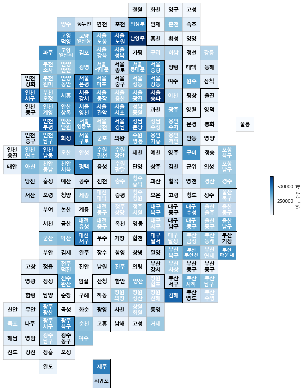

```python
drawKorea('인구수합계', pop, 'Blues')
```

- drawKorea 함수를 사용해서 인구합계를 그려본다.
- 서울송파, 남양주, 화성이 인구가 많다는 것을 알 수 있다.

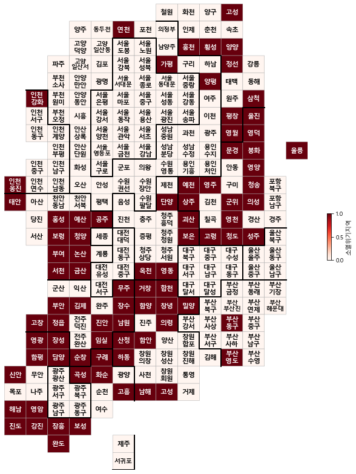

```python
pop['소멸위기지역'] = [1 if con else 0 for con in pop['소멸위기지역']]
drawKorea('소멸위기지역', pop, 'Reds')
```

- drawKorea 함수를 사용해서 인구소멸위기지역을 확인해본다.
- bool형이었던 True, False를 1, 0으로 바꿔서 내타낸다.(색 구분을 위해)
- 광역시 중에서 부산은 동구와 영도가 위험지역에 포함되어있고, 전체적으로 수도권과 일부 광역시를 제외한 나머지 지역들은 심각한 인구소멸 위기지역임을 알 수 있다. 바꿔말하면 인구 밀집현상이 심하다고 할 수있다.

# 5-8 인구 현황에서 여성 인구 비율 확인하기

- 여성인구비율도 확인해 해보도록 한다.
- 예전 1980 ~ 90년대 시대상 우리나라 여성의 높은 낙태율로 인해 여성 인구수가 너무 줄어들어 남녀 비율의 불균형이 심각했던 적이 있었기 때문에 지금은 어떠한지 확인해보도록 한다.

```python
# 함수내용을 일부 수정한다.
def drawKorea(targetData, blockedMap, cmapname):
    gamma = 0.75

    whitelabelmin = 20.

    datalabel = targetData

    #음수가 존재할 수 있기 때문에 절대값으로 변경
    tmp_max = max([ np.abs(min(blockedMap[targetData])),
                                  np.abs(max(blockedMap[targetData]))])
    vmin, vmax = -tmp_max, tmp_max

    mapdata = blockedMap.pivot_table(index='y', columns='x', values=targetData)
    masked_mapdata = np.ma.masked_where(np.isnan(mapdata), mapdata)

    plt.figure(figsize=(9, 11))
    plt.pcolor(masked_mapdata, vmin=vmin, vmax=vmax, cmap=cmapname,
               edgecolor='#aaaaaa', linewidth=0.5)

    # 지역 이름 표시
    for idx, row in blockedMap.iterrows():
        # 광역시는 구 이름이 겹치는 경우가 많아서 시단위 이름도 같이 표시한다.
        #(중구, 서구)
        if len(row['ID'].split())==2:
            dispname = '{}\n{}'.format(row['ID'].split()[0], row['ID'].split()[1])
        elif row['ID'][:2]=='고성':
            dispname = '고성'
        else:
            dispname = row['ID']

        # 서대문구, 서귀포시 같이 이름이 3자 이상인 경우에 작은 글자로 표시한다.
        if len(dispname.splitlines()[-1]) >= 3:
            fontsize, linespacing = 10.0, 1.1
        else:
            fontsize, linespacing = 11, 1.

        annocolor = 'white' if np.abs(row[targetData]) > whitelabelmin else 'black'
        plt.annotate(dispname, (row['x']+0.5, row['y']+0.5), weight='bold',
                     fontsize=fontsize, ha='center', va='center', color=annocolor,
                     linespacing=linespacing)

    # 시도 경계 그린다.
    for path in BORDER_LINES:
        ys, xs = zip(*path)
        plt.plot(xs, ys, c='black', lw=2)

    plt.gca().invert_yaxis()

    plt.axis('off')

    cb = plt.colorbar(shrink=.1, aspect=10)
    cb.set_label(datalabel)

    plt.tight_layout()
    plt.show()
```

```python
pop.head()
```

|  | 광역시도 | 시도 | 20-39세여자 | 20-39세합계 | 65세이상합계 | 인구수남자 | 인구수여자 | 인구수합계 | 소멸비율 | 소멸위기지역 | ID | y | x |
| --- | --- | --- | --- | --- | --- | --- | --- | --- | --- | --- | --- | --- | --- |
| 0 | 강원도 | 강릉시 | 23098.0 | 49384.0 | 37679.0 | 106231.0 | 107615.0 | 213846.0 | 1.226041 | 0 | 강릉 | 3 | 11 |
| 1 | 강원도 | 고성군 | 2529.0 | 7023.0 | 7151.0 | 15899.0 | 14215.0 | 30114.0 | 0.707314 | 1 | 고성(강원) | 0 | 10 |
| 2 | 강원도 | 동해시 | 9753.0 | 21264.0 | 15124.0 | 47166.0 | 46131.0 | 93297.0 | 1.289738 | 0 | 동해 | 4 | 11 |
| 3 | 강원도 | 삼척시 | 7115.0 | 15823.0 | 14610.0 | 35253.0 | 34346.0 | 69599.0 | 0.973990 | 1 | 삼척 | 5 | 11 |
| 4 | 강원도 | 속초시 | 8752.0 | 18708.0 | 12752.0 | 40288.0 | 41505.0 | 81793.0 | 1.372647 | 0 | 속초 | 1 | 10 |

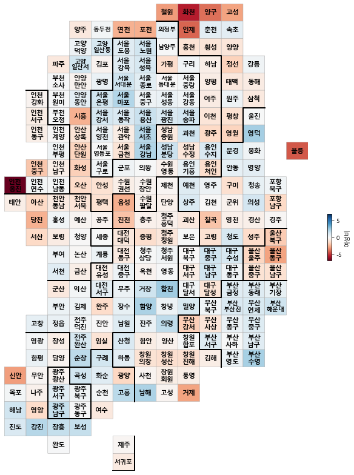

```python
pop['여성비'] = (pop['인구수여자']/pop['인구수합계'] - 0.5)*100
drawKorea('여성비', pop, 'RdBu')
```

- 여성인구수와 합계를 알고 있기 때문에 나눈다음 0.5를 빼는 작업을 해준다. 0이면 여성인구수가 50%인 것이다.
- 그 이유는 drawKorea에 색상 팔레트를 지정할 때 RdBu같은 설정을 사용하면 0을 기준으로 좌우가 다른 색상을 갖도록 할 수 있기 때문이다.
- 인구비율을 시각화 한 결과 파란색으로 갈수록 여성비가 높은 것이고, 빨간색으로 갈수록 여성비가 낮은 것이다.
- 극도로 남성 비율이 높은 몇몇 지역이 눈에 보인다....
- 이것은 여성 인구 전체를 대상으로 한 것이기 때문에 20-30대 여성으로 데이터를 바꾸면 상황은 달라질 것이다.

### 20-30여성비

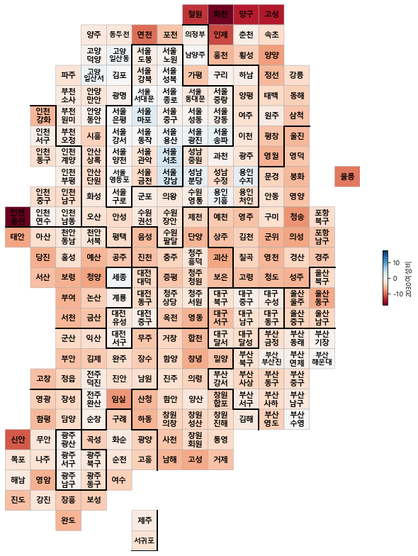

```python
pop['2030여성비'] = (pop['20-39세여자']/pop['20-39세합계']-0.5)*100
drawKorea('2030여성비', pop, 'RdBu')
```

- 20-30대 여성의 전체인구에 대한 비율을 확인해보았다.
- 고령 여성 인구를 제외하고 나면 전국적으로 남성 인구 비율이 높다는 것을 알 수가 있는데 우리나라의 사회문제가 참 심각해보인다.

# 5-9 Folium에서 인구 소멸 위기 지역 표현하기

```python
# pop데이터에서 ID 컬럼을 index로 설정해준다. (Folium에서 쉽게 인식하기 위해)
pop_folium = pop.set_index('ID')
pop_folium.head()
```

| ID | 광역시도 | 시도 | 20-39세여자 | 20-39세합계 | 65세이상합계 | 인구수남자 | 인구수여자 | 인구수합계 | 소멸비율 | 소멸위기지역 | y | x | 여성비 | 2030여성비 |
| --- | --- | --- | --- | --- | --- | --- | --- | --- | --- | --- | --- | --- | --- | --- |
| 강릉 | 강원도 | 강릉시 | 23098.0 | 49384.0 | 37679.0 | 106231.0 | 107615.0 | 213846.0 | 1.226041 | 0 | 3 | 11 | 0.323597 | -3.227766 |
| 고성(강원) | 강원도 | 고성군 | 2529.0 | 7023.0 | 7151.0 | 15899.0 | 14215.0 | 30114.0 | 0.707314 | 1 | 0 | 10 | -2.796042 | -13.989748 |
| 동해 | 강원도 | 동해시 | 9753.0 | 21264.0 | 15124.0 | 47166.0 | 46131.0 | 93297.0 | 1.289738 | 0 | 4 | 11 | -0.554680 | -4.133747 |
| 삼척 | 강원도 | 삼척시 | 7115.0 | 15823.0 | 14610.0 | 35253.0 | 34346.0 | 69599.0 | 0.973990 | 1 | 5 | 11 | -0.651590 | -5.033812 |
| 속초 | 강원도 | 속초시 | 8752.0 | 18708.0 | 12752.0 | 40288.0 | 41505.0 | 81793.0 | 1.372647 | 0 | 1 | 10 | 0.743951 | -3.217875 |

```python
import folium
import json
import warnings
warnings.simplefilter(action='ignore', category=FutureWarning)
```

```python
# json파일을 연결해 '인구수합계'를 표현해본다.

geo_path = '../data/05. skorea_municipalities_geo_simple.json'
geo_str = json.load(open(geo_path, encoding='utf-8'))

map = folium.Map(location=[36.2002, 127.054], zoom_start=7)
map.choropleth(geo_data = geo_str,
               data = pop_folium['인구수합계'],
               columns = [pop_folium.index, pop_folium['인구수합계']],
               fill_color = 'YlGnBu', #PuRd, YlGnBu
               key_on = 'feature.id')

map
```

[interactive chart not shown]

```python
# json파일을 연결해 '소멸위기지역'을 표현해본다.

map = folium.Map(location=[36.2002, 127.054], zoom_start=7)
map.choropleth(geo_data = geo_str,
               data = pop_folium['소멸위기지역'],
               columns = [pop_folium.index, pop_folium['소멸위기지역']],
               fill_color = 'PuRd', #PuRd, YlGnBu
               key_on = 'feature.id')

map
```

[interactive chart not shown]

```python
# 데이터를 새 파일로 저장해준다.
draw_korea.to_csv("../data/05. draw_korea.csv", encoding='utf-8', sep=',')
```